# Analyse des créations de communes nouvelles 2012-2022 - Étude de la néotoponymie

G. Bideau et F. Giraut

24 mars 2022

# _________

> **NB : Le texte présenté ici est une version de l’article publié dans *L’Espace politique* mais mis à jour avec les données de la géographie administrative au 1<sup>er</sup> janvier 2022.**

Gabriel Bideau et Frédéric Giraut, « Faire territoire : logiques de la dénomination des communes nouvelles françaises », *L’Espace Politique* [En ligne], 43 | 2021-01, http://journals.openedition.org/espacepolitique/9898 ; DOI : https://doi.org/10.4000/espacepolitique.9898

Dans ce script, les données sont localisées dans un répertoire nommé `data`. À modifier éventuellement (les données utilisées sont mises à disposition dans le cadre d’une démarche de science ouverte et reproductible).

La construction de ces données est précisée dans un *data paper* en cours de publication pour la revue *Cybergéo*.

Les données et le script sont accessibles à l’adresse suivante : https://nakala.fr/10.34847/nkl.ef6b33ct, une version html est plus aisément lisible à cette adresse : https://gbideau.github.io/CN_Fr_Neotopo/.

## Résumé

Cet article étudie les noms des communes nouvelles françaises, soit 787 nouvelles entités créées par la fusion de 2 536 communes historiques entre 2012 et le 1er janvier 2022. Sont utilisées les données de la statistique publique pour créer une typologie exploratoire, d’abord élaborée à partir des régularités de construction (confirmation, juxtaposition ou innovation dénominatives entre autres). La réalisation de cette typologie est détaillée et les principaux résultats analysés. L’ensemble (données, typologie et code du script) est mis à disposition dans le cadre d’une recherche ouverte et reproductible. L’analyse du sens des termes utilisés dans les néotoponymes fait l’objet d’une seconde typologie grâce à la consultation de la presse régionale. Cette contribution répond à trois questions de recherche. Alors que la littérature scientifique sur la toponymie s’est particulièrement développée ces dernières décennies, il s’agit d’interroger l’adéquation de ses grandes orientations à l’objet des communes nouvelles. Tout d’abord, comment les acteurs se sont-ils saisis de cette nécessité de création néotoponymique ? Nous montrons le poids déterminant des élus, avec une consultation plus ou moins importante de la population et très rarement des professionnels de la communication. Ensuite, nous observons comment la néotoponymie révèle les rapports de force entre collectifs territorialisés. En effet, les types de dénominations ne sont pas répartis de la même manière selon le nombre de communes participant à la fusion (pour les fusions de deux communes, la juxtaposition est préférée, la confirmation d’un nom unique de commune ou l’innovation emportant davantage l’adhésion pour des groupes plus importants), selon la domination d’une commune centre ou encore le profil des communes par rapport au zonage urbain (les centres urbains vont par exemple davantage choisir la confirmation ou une juxtaposition, les périphéries urbaines préférant l’innovation). Enfin, il s’agit de montrer que là où la référence à la ville-centre ne l’emporte pas, la néotoponymie est alors dominée par deux tendances. D’une part, elle est outil patrimonial et/ou de marketing territorial avec l’utilisation de termes à forts potentiels de promotion et une situation affirmée dans un arrière-pays qui accroît les ressources territoriales mobilisables. D’autre part, on observe fréquemment une forme de banalisation et d’uniformisation des toponymes autour de noms communs, notamment orographiques ou hydrographiques.

Mots-clés : commune nouvelle, néotoponymie, typologie, marketing territorial, toponymie, France

## Abstract

This paper aims at geographically analyze the names of the 787 new municipalities (“communes nouvelles”), created in France between 2012 and January 1, 2022. Public statistics data are used to elaborate an exploratory typology of the 2,536 historical municipalities that have merged into new local bodies of governements, discussing recurring schemes of construction in a first typology (consolidation, juxtaposition, innovation). A second typology explores the meaning of terms used in neotoponymy with assistance of regional press records. All data sets and reproducible code are made available according to reproducible research principles. This contribution is threefold. First, elaborating on a growing scientific literature on toponymy, we examine the relevance of such an analysis on communes nouvelles’s toponymy. We examine how actors dealt with the need to create a new toponymy? We show that elected officials had a stronger influence, than inhabitants or marketing experts. We then focus on how neotoponymy has revealed the balance of powers between territorialized groups. The different categories of neotoponymy used are not distributed evenly between mergers (two communes will prefer juxtaposition; confirmation of a central municipality is preferred for larger mergers). Results vary highly between urban centers and urban peripheries. Finally, we analyze how visibility and heritage toponymy, vs a more trivial and standardized use of topographic features are used for territorial marketing.

Keywords: new municipality, neotoponymy, typology, territorial marketing, toponymy, France

# INTRODUCTION

Depuis 2012, la France connaît l’un des mouvements de fusions de communes le plus intense de son histoire municipale. En quelques années (entre 2012 et le 1er janvier 2022 pour le cadre de cette étude[^1]), environ 780 communes nouvelles ont été créées à partir du regroupement de plus de 2 500 communes, que nous appellerons fusionnantes[^2]. Cela s’inscrit dans un mouvement général de recompositions territoriales et de nouveau régionalisme. La décennie 1980 a été marquée par un aggiornamento rationnalisateur et décentralisateur qui a affecté tous les niveaux dans différents contextes (Antheaume and Giraut 2005, cop. 2005) et notamment le niveau municipal (Barlow and Wastl-Walter 2004 ; Meligrana 2004). On y observe notamment la promotion du gouvernement métropolitain qui peut être vu comme un repositionnement de l’État (Brenner 2004 ; Estèbe 2008), ou celui des bassins de vie et des régions reconfigurées (Deas and Lord 2006 ; Giraut 2005). Dans le contexte français, cela fait suite à la promotion de l’intercommunalité (Gerbaux 1999 ; Giraut 2002 ; Offner 2006). Cette dernière, d’abord technique, suppléait jusqu’à présent aux besoins de coopération locale et urbaine pour les services de base. En effet, la marqueterie municipale, calée depuis la Révolution sur le maillage des paroisses, est restée très fine aussi bien en milieu rural qu’urbain après une vague très limitée de fusions de communes au XIXe et au début du XXe liées à l’urbanisation des grandes villes (Edelblutte, 2000). Les années 1970 ont été marquées par l’échec retentissant d’une tentative de fusions massives avec la loi dite Marcellin (Offner 2006 ; Tellier 2017). Prenant acte de cet échec, les pouvoirs publics ont proposé des modèles différenciés et évolutifs de coopération (Gerbaux 1999 ; Guichard 1976) ; l’intercommunalité de projet s’est alors affirmée progressivement et selon des modalités à géométrie variable (Estèbe 2008 ; Giraut 2002 ; Vanier 2008). Le récent phénomène des communes nouvelles fournit donc, en démarrant bien plus tard que celui des intercommunalités (les premières communes nouvelles ont été créées alors que l’intégration et la carte intercommunale s’achevaient), un champ d’étude particulièrement intéressant, à plusieurs titres. Déjà envisagé sous des angles juridique (Lenfant 2018), d’information à destination des citoyens ou des élus (Aubelle 2016 ; Verpeaux and Pecheul 2016 ; Ville 2017), de science politique (Frinault 2017 ; Kada 2017; Pasquier 2017) et géographique (Bideau 2019), ce dernier ne l’a pas encore été, de manière approfondie, sous l’angle du choix des noms devant désigner ces nouvelles entités, or le débat sur les noms est souvent fait de controverses et de positionnement contradictoires d’acteurs de la fusion. Nous pensons que la néotoponymie (processus qui conduit à nommer de nouveaux territoires et corpus constitué par ces nouveaux noms) est révélatrice de problématiques géopolitiques et territoriales locales primordiales dans le processus de création de ces entités, et que son étude est un moyen d’en rendre compte.

Le plan de cet article suit la logique de notre raisonnement (présenté dans la figure 1), à savoir une réflexion s’appuyant sur différentes sources et analyses exploratoires pour élaborer une typologie à valeur analytique. Nous présenterons donc d’abord les grandes orientations de la recherche en néotoponymie et comment elles peuvent s’appliquer à la question des communes nouvelles (section 1), puis nous aborderons la question des processus permettant d’élaborer les néotoponymes (section 2), avant de présenter les typologies réalisées et les principaux résultats (sections 3 à 5).

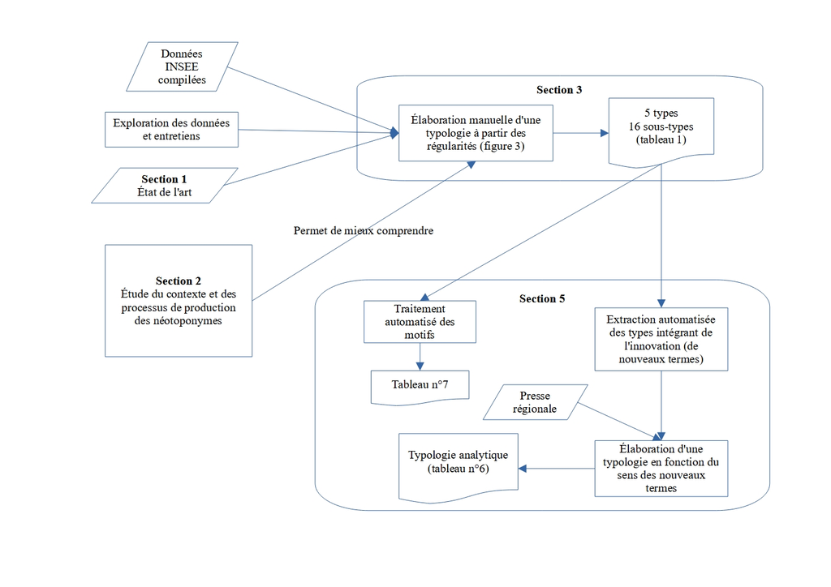

**Figure 1 : Structure générale de la réflexion et de l’article**

# LES APPORTS DES APPROCHES DE TOPONYMIE POLITIQUE[^3] POUR ABORDER LES COMMUNES NOUVELLES

Au croisement de nombreuses disciplines, l’étude des noms de lieux sous un angle socio-politique s’est révélée particulièrement féconde ces dernières décennies. Les anglophones parlent de critical toponymy et les francophones plutôt de toponymie politique pour désigner un ensemble de travaux récents auxquels participent des disciplines telles que l’histoire, la géographie, la linguistique, l’anthropologie et la sociologie. Ces travaux s’inscrivent dans une dynamique déjà bien décrite (Giraut and Houssay-Holzschuch 2021 ; Rose-Redwood, Alderman, and Azaryahu 2010 ; Vuolteenaho and Berg 2009). Bien que la dimension critique des travaux les plus anciens n’ait pas toujours été perçue à sa juste valeur (Bigon 2016 ; Chamboredon 1988), force est de constater que, depuis les années 1980, l’analyse des noms comme discours pouvant être déconstruit s’est généralisée, en lien avec ce qu’on a appelé le « tournant critique » et a conduit à des efforts de théorisation (Bigon 2020 ; Eades 2016 ; Giraut 2016 ; Rose-Redwood, Alderman, and Azaryahu 2017 ; Rusu 2021). Des jalons importants ont été posés, faisant intervenir de manière comparative plusieurs cas exemplaires autour des questions de nominations de territoires émergents qui nous intéressent particulièrement ici (Cardoso and Meijers 2017 ; Giraut, Guyot, and Houssay-Holzschuch 2008).

Quelques grandes orientations de ces études sur la dénomination des noms de lieux nous semblent devoir être soulignées car offrant un cadre problématique et conceptuel à notre étude. Il s’agit, d’une part, de la focalisation sur les processus de dénomination et leur contextualisation. Sont importantes, d’autre part, les questions de la dimension économique de la néotoponymie ainsi que de la promotion territoriale qu’elle implique parfois.

Outre les nombreux travaux sur les changements d’odonymes à la faveur des changements de pouvoir, notamment dans l’ancien bloc communiste[^4], les études de toponymie critique portent fréquemment sur des espaces faisant l’objet d’appropriations conflictuelles, en lien avec des processus plus ou moins anciens de conquête et/ou de colonisation. Après les premiers travaux sur les noms de lieux, qui ont pu être désignés comme l’œuvre de « *botanic collector* » (Wright 1929), ce sont souvent des terrains coloniaux qui ont été au cœur des attentions à partir des années 1980 (Rose-Redwood, Alderman, and Azaryahu 2010). En effet, dans ces derniers étaient particulièrement visibles des concurrences entre des toponymies aux origines différentes et surtout mouvantes.

Une autre grande orientation que prennent les travaux de toponymie critique ou politique (n’étant bien évidemment pas exclusive de la première), est la question de la « *commodification* » ou marchandisation des noms de lieux ainsi que celle, liée, du marketing territorial. Alors que les parallèles à faire entre les noms de lieux et ceux des marques ont été bien montrés (Medway and Warnaby 2014), l’aspect marchandisé des dénominations a été souligné dans ses dimensions urbaine et territoriale (Light and Young 2015), au Chili (Amilhat Szary 2008), en Afrique du Sud (Giraut, Guyot, and Houssay-Holzschuch 2008), aux États-Unis et au Royaume-Uni (Cardoso and Meijers 2017) ainsi qu’en Chine où ses conséquences (le changement de nom a-t-il un effet ou non ?) sont très discutées, particulièrement à partir d’analyses de données économiques (Guo and Zhang 2019 ; Ji 2017 ; Lu, Wu, and Xie 2018).

Le questionnement sur les cadres théoriques découle en particulier des terrains évoqués plus haut. Dans une dynamique similaire aux travaux de J. Robinson (Robinson 2006), le calque de cadres occidentaux sur des territoires ayant fait l’objet d’une colonisation (ou, tout au moins, faisant cohabiter une toponymie dominante et une toponymie indigène dominée) a été questionné (voir, par exemple, (Collignon 1996)). La dimension fluctuante et non institutionnelle de la toponymie vernaculaire et alternative (Bigon 2020 ; Giraut 2020 ; Lajarge 2002) et le souhait de prendre en compte les processus de contestation qui nuancent la question de l’importance du nom officiel final (Karlander 2017 ; Zimmerbauer and Paasi 2013) a également conduit à ne pas aborder ces questions avec les cadres normatifs et conceptuels des experts en standardisation toponymique.

Plusieurs auteurs ont plutôt proposé des grilles d’analyse théoriques, conduisant à s’intéresser aux dynamiques amenant à l’attribution d’un nom. J. Vuolteenaho et L.D. Berg ont par exemple mis en avant en l’importance de « *the intersection of naming, place-making, and power* * » (Vuolteenaho and Berg 2009). En plaidant pour qu’on s’intéresse davantage au processus de dénomination (le *place naming*) plutôt qu’aux noms eux-mêmes (*place name*), F. Giraut et M. Houssay-Holzschuch reprennent cette approche et utilisent le concept de « dispositif » développé par Michel Foucault pour insister sur le fait qu’interviennent des contextes, des technologies et des acteurs (Giraut 2016). Un toponyme peut ainsi être caractérisé par sa signification, les acteurs qui ont conduit à son choix, son histoire référentielle (c’est-à-dire les autres territoires qui ont pu être définis par ce toponyme dans le passé) ou encore son utilisation contemporaine (s’il désigne d’autres entités spatiales).

Il s’agira donc de voir dans quelle mesure le passé toponymique communal impacté par la christianisation des paroisses puis par l’entrée dans la municipalisation républicaine est aujourd’hui traversé par les dynamiques mises en exergue par la toponymie politique que sont les rapports de pouvoirs, les phénomènes de résistance culturelle ou encore le marketing territorial. Plusieurs problématiques ont déjà été formulées dans l’optique d’étudier les noms des communes nouvelles en tant que discours (Giraut 2020). Nous proposons de les développer ici. Elles conduiront à se demander ce qui rend la néotoponymie des communes nouvelles plutôt spécifique ou générique au regard des tendances observées dans d’autres contextes, et en quoi la néotoponymie des communes nouvelles constitue un discours sur la manière dont se construit le territoire aujourd’hui.

Cet article propose un jalon pour l’étude des noms des communes nouvelles à l’échelle nationale, se concentrant d’abord sur les grandes tendances et les grandes orientations d’une étude typologique. Nous évoquerons plusieurs cas particuliers sans pour autant proposer une étude poussée de terrains spécifiques, approche qui sera sans doute nécessaire pour avoir une vision plus locale et pragmatique des processus de décision et des résistances qui ont pu avoir lieu, ces dernières constituant un élément déterminant pour comprendre, en creux, le processus de dénomination (Karlander 2017 ; Zimmerbauer and Paasi 2013).

Enfin, un enjeu trop rarement pris en compte par les études sur la dénomination des lieux, et particulièrement la néotoponymie, porte sur la reproductibilité des analyses et l’aspect cumulatif des recherches portant sur des corpus. Nous avons déjà cité plusieurs travaux ayant traité des modifications des noms de communes françaises, sans que les données sur lesquelles s’appuient ces derniers soient toujours clairement identifiées, sans que l’on puisse reproduire les analyses statistiques proposées, ni qu’on puisse expliquer les différences, parfois sensibles, des résultats proposés (Delattre 2007 ; Guerrin 1998b, 1998a).[^6] Dans une dynamique de science ouverte, pour permettre justement le prolongement de nos analyses, nous mettons à disposition un script présentant les traitements mis en œuvre ainsi que les données utilisées[^7]. Notre étude se fondera sur l’analyse statistique de l’ensemble des communes nouvelles créées entre 2012 et le 1er janvier 2022.

Cette contribution répond à trois questions de recherche, qui guideront notre raisonnement. Tout d’abord (Q1), comment les acteurs se sont-ils saisis de cette nécessité de création néotoponymique ? Y a-t-il eu des processus d’information et de consultation de la population ? Des ressources professionnelles ont-elles été mobilisées (archivistes, historiens, publicitaires, agences de communication, agences spécialisées dans la concertation…) ? Ensuite (Q2), nous nous demanderons comment la néotoponymie révèle, ou non, les rapports de force entre collectifs territorialisés. Dans quelle mesure retrouve-t-on une référence exclusive ou principale à une commune centre au sein du nouvel ensemble ? Certains types sont-ils choisis par des fusions concernant peu de communes, et d’autres par les regroupements plus larges ? Quelles sont les caractéristiques des communes dont le nom s’impose à l’ensemble ? Quelles stratégies toponymiques sont développées pour éviter la prédominance d’une commune centre ou dominante ? Enfin (Q3), nous verrons dans quelle mesure la néotoponymie devient un outil patrimonial et/ou de marketing. A-t-on plutôt une perte, une conservation ou une mise en avant de toponymes religieux, issus de langues régionales, faisant référence à des faits historiques, liés au relief et à l’hydrographie, à des équipements ou des aménagements remarquables et patrimonialisés ? Au vu des ajouts, peut-on parler d’un « bonus identitaire » (utilisation d’un élément commun d’attachement, de quelque type qu’il soit) ou y a-t-il plutôt une forme de banalisation et d’uniformisation des toponymes par neutralisation interne ?

# LES CONDITIONS DE PRODUCTION DES NOUVEAUX NOMS

Une première dimension de l’analyse porte sur les conditions d’élaboration des noms des communes nouvelles, qu’il s’agisse des processus mis en œuvre ou des acteurs mobilisés. En effet, en créant une nouvelle entité administrative et territoriale, la fusion en commune nouvelle implique le choix d’un nom pour cette dernière. La décision est prise, en dernier ressort, par le préfet qui publie un arrêté désignant le nouveau nom. Cependant, si la décision appartient au préfet, il doit la prendre « au vu des avis émis par les conseils municipaux » ([article L2113-6](https://www.legifrance.gouv.fr/codes/article_lc/LEGIARTI000030365883/)).

Alors que les procédures imposées pour le changement de nom d’une commune sont particulièrement longues et complexes, ce n’est pas le cas pour les noms des communes nouvelles. Première différence : il s’agit d’un arrêté préfectoral et non pas d’un décret, ce qui était pourtant la règle pour un changement de nom (article L2111-1 du Code général des collectivités territoriales, il fallait même que ce dernier soit pris par le Conseil d’État jusqu’en 2018). Autre différence notable : rien dans la loi n’indique d’éventuelles règles à respecter sur le nouveau nom. Alors que depuis 1948 une Commission de Révision du Nom des Communes (CRNC) était théoriquement sollicitée pour les changements de noms, cette dernière n’a pas été mobilisée concernant les fusions de communes (elle a d’ailleurs été supprimée en 2019). Comme le rappelle C. Guerrin (1998a), cette dernière avait pu refuser des appellations considérées comme trop commerciales (Vitrolles-en-Provence), contrevenant aux AOC (Pommiers-en-Beaujolais) ou tout simplement inadaptées d’après elle (Saint-Hélène-sur-Mer alors que la commune ne donne pas sur de l’eau salée, Louisfert-en-Poésie considérée comme trop fantaisiste) mais « En ce qui concerne le nom des “communes nouvelles,” […] la Commission consultative de révision du nom des communes n’est pas saisie. » (Commission nationale de toponymie, 2016, p. 4).

Si la décision appartient au préfet, il est bien noté que les conseils municipaux, par leurs avis, peuvent avoir un poids déterminant, surtout lorsqu’ils s’expriment par le biais de délibérations concordantes. Même lorsqu’ils ne réussissent pas à se mettre d’accord, c’est encore à eux que le préfet soumet une proposition, pour avis. Les conseils municipaux sont, de leur côté, libres des moyens mis en œuvre pour réfléchir au nouveau nom. Dans la très grande majorité des cas, la décision a été prise par les conseils municipaux seuls, sans consultations extérieures. D’autres communes ont, elles, choisi de mobiliser les habitants à un ou plusieurs moments du processus de réflexion. Le schéma-type qui se dessine dans plusieurs situations[^9] est le suivant (cf. aussi figure 2) :

- Large consultation pour collecter des propositions de noms, parfois de l’ensemble des habitants, parfois des conseils municipaux seuls, parfois lors d’ateliers plus ou moins cadrés.
- Ces propositions sont triées, soit *a priori* en fonction de certains critères (par exemple à Chemillé-en-Anjou [Maine-et-Loire] où devait figurer les noms de Chemillé ou Chemillois) soit *a posteriori* lors d’une sélection par un groupe de travail, composé de manière variable.
- Un petit nombre de propositions est soumis à l’avis (le plus souvent consultatif) de la population ou d’élus.
- Le choix est finalement tranché par les conseils municipaux, ces derniers transmettant le nom aux préfets qui rédigent l’arrêté.

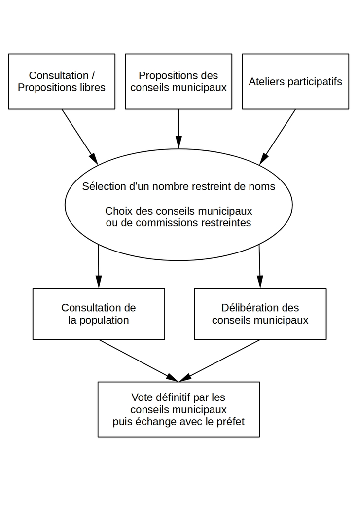

**Figure 2 : Différentes possibilités dans le processus d’élaboration du nom**

Des modalités pratiques multiples ont pu être engagées pour permettre ces différentes étapes : boîtes aux lettres, consultations numériques, réunions publiques, groupes de citoyens volontaires ou encore mobilisation des scolaires de la commune. Ces éléments gagneraient à être étudiés de manière approfondie, en lien avec les analyses des processus participatifs. Les enjeux de ces consultations sont nombreux. On peut évoquer par exemple la place réelle laissée à la population, qui est parfois consultée pour des propositions, parfois uniquement pour choisir au sein d’un panel restreint, parfois non sollicitée dans le processus. Le mode d’expression rendu possible lorsqu’il y a consultation est lui aussi déterminant : il s’agit parfois d’avis consultatifs, d’initiatives ou de propositions, parfois de votes mais alors les modalités de scrutin (nombre de tour, possibilité de voter pour plusieurs noms, etc.) peuvent être décisives, tout comme l’arbitrage final. Nous évoquerons plus bas un autre enjeu que sont les ressources utilisées. La manipulation des modes d’expression a été bien montrée, dans un autre contexte, lors du choix ayant conduit à l’appellation de Thunder Bay (en Ontario), ce nom ayant été choisi en particulier car trois noms étaient en compétition : Lakehead, The Lakehead et Thunder Bay, les deux premiers étant en concurrence directe et s’étant en partie neutralisés dans le cadre du vote à un tour qui avait été mis en place (Cardoso and Meijers 2017). On sait par ailleurs, que pour les nouveaux noms de régions, le nom de Grand-Est, finalement choisi, ne figurait pas dans la sélection initiale opérée par un comité d’experts et de citoyens (Giraut, 2016). Dans le cas des communes nouvelles, c’est dans une fusion récente qu’on trouve un exemple assez net de choix partiel laissé aux habitants puisque dans le cas de la fusion de La Faute-sur-mer et de L’Aiguillon-sur-Mer (actée au 1er janvier 2022), trois propositions ont été soumises aux habitants[^10]. Se combinaient alors la neutralisation par un haut lieu commun (Cap-d’Arcay), la promotion du dénominateur commun en terme de configuration et de positionnement (Les-Pointes-sur-Mer), au risque de la dénomination générique et enfin le référent de la localité principale agrémenté d’une description topographique qui évoque le littoral et l’autre localité (Aiguillon-la-Presqu’île). Cependant, une proposition n’apparaissait pas (alors qu’elle était souhaitée par une partie des habitants) : la juxtaposition des deux noms (L’Aiguillon-La Faute ou *vice versa*). Celle-ci marque un fort attachement aux noms originels et la tentation de les conserver, quitte à perdre le suffixe touristique de « sur-mer ». Par rapport à la figure 2, la place laissée à la population était donc uniquement lors de la troisième étape. On observe bien que la consultation de la population relève du seul choix des conseils municipaux.

Dans son courrier datant du 18 avril 2017, le directeur des collectivités locales invitait les préfets à consulter, pour avis toujours, le service des archives départementales. Ce point, comme la consultation de la population, a fait l’objet de propositions d’amendements lors des débats parlementaires pour les rendre obligatoires. Ils n’ont cependant jamais été adoptés. S’il n’est pas aisé de quantifier l’utilisation qui a été faite de cet avis, force est de constater que cela n’intervenait que tard dans le processus d’élaboration. Certaines communes ont pu mobiliser des historiens locaux ou des documents d’archives pour décider du nouveau nom, cela a par exemple été le cas de la commune-nouvelle « Le Val-Doré » (Eure) dont le nom a été proposé par les archives départementales (le choix initial se portant sur « Les Deux Rives ») à partir d’un toponyme latin attesté au XIe siècle (Aurea valles ayant donné Orvaux, une des communes déléguées). Des agences de communication ou publicitaires ont peut-être été sollicitées mais nous n’en avons pas retrouvé la trace dans la presse locale. De fait, il faut avoir en tête, d’une part que plus de la moitié des communes nouvelles créées comportent moins de 1700 habitants et disposent donc de peu de budget. Cela conduit à écarter l’hypothèse du recours non exceptionnel à des professionnels extérieurs sur la seule question du nom. Le recours à des cabinets de conseil a été plus fréquent sur les questions réglementaires et fiscales, c’est-à-dire que la quasi totalité des maires ou élus que nous avons rencontrés y avaient eu recours. Dans ce dernier cas, la technicité du sujet paraissait sans doute trop importante (et le sujet plus sensible ?), alors que la question de la néotoponymie pouvait sembler plus abordable. D’autre part, les responsables politiques (maires et conseillers municipaux) ont souvent considéré qu’ils étaient les plus à même (et que c’était leur rôle) de définir l’identité et donc le nom des nouvelles entités ; un peu à la manière de ce que Georges Clemenceau aurait dit de la Guerre avec les militaires : quelque chose de trop grave pour le confier à des spécialistes de la communication (ou des archives). Ainsi le maire de Valezan (commune nouvelle de La Plagne-Tarentaise, février 2017) : « Tout le monde a participé, il y a eu un sorte d’appel au sein de la Commune nouvelle. On n’a pas pris un cabinet extérieur, cela s’est fait d’une façon collégiale. »

On peut, enfin, noter quelques cas de controverses au moment des choix des communes nouvelles. La distinction qui a pu être faite entre contestation endogène et contestation exogène est ici tout à fait utile (Medway and Warnaby 2014). Lorsque l’affaire a été l’objet d’un contentieux frontal et médiatisé, il s’agissait le plus fréquemment de rivalités exogènes entre entités anciennes ou naissantes pour l’appropriation d’un lieu conférant une visibilité et une attractivité touristique. C’est ainsi le cas de la station de montagne de La Plagne (deux communes nouvelles intégrant celle-ci dans leur nom) ou du lac de Guerlédan (une action en justice lancée par des communes voisines, déboutées en 2017 puis 2019, considérait comme abusive l’utilisation de ce nom par la commune nouvelle). Les rivalités internes, endogènes, ont de fait existé mais ont pu être surmontées sans trop de recours à des arbitrages judiciaires ou administratifs externes. On rejoint en cela l’analyse de K. Zimmerbauer et A. Paasi (2013) en Finlande où ils montrent l’attachement affectif aux entités fusionnées qui passe par une résistance extrajudiciaire basée sur le maintien (au moins momentané) de l’usage de noms des entités fusionnées. On note cependant un certain nombre d’arbitrages préfectoraux. Les conflits qui ont pu intervenir durant le processus, parfois couverts par la presse régionale, mériteraient une approche plus spécifique. Ce point pourrait faire l’objet d’enquêtes de terrains particulièrement intéressantes. Cependant on peut considérer comme on le verra que nombre de noms génériques sont des noms de compromis issus justement d’une neutralisation de propositions beaucoup plus spécifiques, à valeur patrimoniale ou territoriale.

# TYPOLOGIE

Les problématiques évoquées plus haut nous ont invité à formaliser une typologie qui a été construite dans un but d’analyse. Plusieurs typologies de néotoponymes ont été proposées dans des contextes francophone : P.-A. Landel et N. Senil ont différencié des modèles productivistes, patrimoniaux ou hybrides (Landel and Senil 2008) tandis que G. Bailly a davantage insisté sur l’élément de référence du nouveau nom comme le naturalisme, le patrimoine ou encore la solidarité (Bailly 2008). À partir du contexte suisse, L. Destrem et le groupe Metronom ont proposé des types parfois axés sur la structure de ce dernier (confirmation, mot-valise etc) et d’autres sur leur signification (naturalisation, promotion etc) (Destrem and Métronom 2016).

Ces propositions reposent sur le parti-pris d’identifier les grandes tendances en regroupant les cas complexes dans une catégorie qui fait prévaloir une des caractéristiques du néotoponyme. Le nom d’une commune nouvelle peut cependant être construit d’abord sur la confirmation d’une des communes fusionnantes mais en y ajoutant un autre terme faisant référence à un élément patrimonial ou naturel. Dans ce cas, une typologie ne mentionnant que « Confirmation » ou « Innovation » risquerait de se révéler peu manipulable ou insuffisamment explicite.

Nous avons donc construit notre typologie sur plusieurs niveaux. En premier lieu, nous distinguons cinq grandes catégories, un premier niveau d’exploration nous ayant permis de faire émerger certaines régularités déjà évoquées comme la confirmation, la juxtaposition, l’innovation etc. Tout d’abord, les communes où une des entités impose son nom, en totalité ou en partie (type 1). Nous observons, d’autre part, si certains noms sont construits avant tout sur la juxtaposition de plusieurs noms (type 2). Dans un certain nombre de cas, la néotoponymie est principalement constituée d’éléments qui ne sont pas présents dans les noms des anciennes communes, on parle alors d’innovation (type 3) sauf dans de cas de la création d’un mot-valise (mot nouveau élaboré à partir de la contraction de tout ou partie des noms des anciennes communes, type 5). Enfin, est traité à part le cas de l’unification de communes à partir d’un dénominateur commun (type 4).

Il arrive que les noms des communes nouvelles répondent parfaitement aux critères spécifiés dans ces cinq grands types. Cependant de nombreux cas se trouvent être soit hybrides soit méritant des précisions quant aux détails de la composition néotoponymique. Nous avons donc élaboré des sous-catégories, généralement en fonction de la structure du nom (ajouts de nouveaux termes, troncatures etc.).

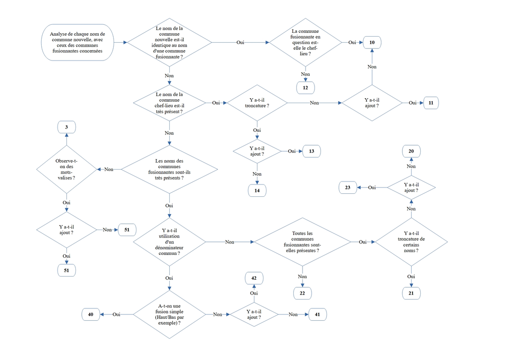

- Confirmation
  - 10. Confirmation de la commune qui devient chef-lieu.
  - 11. Confirmation de la commune qui devient chef-lieu avec adjonction d’un autre terme.
  - 12. Confirmation mais d’une commune n’étant pas le chef-lieu.
  - 13. Confirmation de la commune qui devient chef-lieu mais avec troncature et adjonction d’un autre terme (donc simplement persistance d’un mot issu de la commune devenant chef-lieu).
  - 14. Confirmation de la commune qui devient chef-lieu mais avec troncature.
- Juxtaposition
  - 20. Juxtaposition des noms de toutes les communes fusionnantes.
  - 21. Juxtaposition avec troncature : une ou plusieurs communes voient leurs noms raccourcis (mais toutes les communes sont mentionnées).
  - 22. Juxtaposition de termes venant d’une partie des communes seulement.
  - 23. Juxtaposition avec adjonction : les noms de toutes les communes sont repris avec ajout de nouveaux termes.
- Innovation
  - 3. Le nouveau nom n’est celui d’aucune des communes fusionnantes. Sont notées dans ce type les communes nouvelles portant le seul nom d’un fleuve ou d’une région mentionnée seulement dans certaines communes : ex. Le Mené fusionnant sept communes dont Saint-Gilles-du-Mené ou Saint-Jacut-du-Mené.
- Unification
  - 40. Lorsqu’un « haut » et un « bas » sont fusionnés (ou dessus/dessous etc.) sans retrait ni ajout.
  - 41. Utilisation d’un dénominateurs communs (ex : Fursac composée de Saint-Étienne-de-Fursac et de Saint-Pierre-de-Fursac).
  - 42. Utilisation d’un dénominateur commun avec adjonction d’un ou plusieurs termes.
- Mot-valise
  - 50. Collage d’une partie du nom de toutes les communes.
  - 51. Collage d’une partie du nom de toutes les communes avec ajout d’autres termes.

###### Code : import des données

###### Code : import de la typologie

**Tableau 1 : Typologie des toponymes des communes nouvelles françaises, 2012-2022**

Effectifs des groupes de néotoponymes

| Type | Communes fusionnantes Nombre | Communes fusionnantes Pourcentage | Communes nouvelles Nombre | Communes nouvelles Pourcentage | Communes nouvelles Nombre de communes fusionnantes (moyenne) |
| --- | --- | --- | --- | --- | --- |
| Confirmation (1) dont : | 1066 | 42 | 284 | 36.1 | 3.8 |
| 10 | 347 | 13.7 | 136 | 17.3 | 2.6 |
| 11 | 410 | 16.2 | 82 | 10.4 | 5 |
| 12 | 5 | 0.2 | 2 | 0.3 | 2.5 |
| 13 | 274 | 10.8 | 56 | 7.1 | 4.9 |
| 14 | 30 | 1.2 | 8 | 1 | 3.8 |
| Juxtaposition (2) dont : | 485 | 19.1 | 221 | 28.1 | 2.2 |
| 20 | 248 | 9.8 | 124 | 15.8 | 2 |
| 21 | 180 | 7.1 | 84 | 10.7 | 2.1 |
| 22 | 47 | 1.9 | 8 | 1 | 5.9 |
| 23 | 10 | 0.4 | 5 | 0.6 | 2 |
| Innovation (3) dont : | 905 | 35.7 | 247 | 31.4 | 3.7 |
| 3 | 905 | 35.7 | 247 | 31.4 | 3.7 |
| Unification (4) dont : | 30 | 1.2 | 14 | 1.8 | 2.1 |
| 40 | 10 | 0.4 | 5 | 0.6 | 2 |
| 41 | 12 | 0.5 | 6 | 0.8 | 2 |
| 42 | 8 | 0.3 | 3 | 0.4 | 2.7 |
| Mot-valise (5) dont : | 50 | 2 | 21 | 2.7 | 2.4 |
| 50 | 44 | 1.7 | 18 | 2.3 | 2.4 |
| 51 | 6 | 0.2 | 3 | 0.4 | 2 |
| Ensemble | 2536 | 100 | 787 | 100.1 | 3.2 |

La cartographie des types de néotoponymes ne permet pas d’observer une répartition spécifique de l’un ou l’autre. La polarisation des créations de communes nouvelles dans certaines régions (en particulier Normandie, Anjou, Savoie…) est très nette et a déjà été commentée (Aubelle 2016 ; Bideau 2019). Elle ne laisse cependant pas émerger une préférence marquée, dans quelque espace qu’il soit, pour des types particuliers.

# DES NÉOTOPONYMES RÉVÉLATEURS DE LA GÉOPOLITIQUE INFRACOMMUNALE

## DES NÉOTOPONYMES TRÈS INFLUENCÉS PAR LA COMPOSITION

La géopolitique infracommunale paraît bien avoir une influence déterminante sur le nom des communes nouvelles : le tableau 1 nous invite à répondre par l’affirmative à la problématique postulant un lien entre le type de néotoponymie et le nombre de communes se regroupant. Y a-t-il effectivement une corrélation statistique entre le nombre de communes fusionnantes et l’appartenance à une des catégories de néotoponymie ? Un test de Chi² à partir des données du tableau n° 2 nous permet de rejeter l’hypothèse d’indépendance des deux variables que sont la néotoponymie et le nombre de communes fusionnantes[^12]. Dans une situation où le regroupement de deux ou trois communes est très nettement la norme (la médiane est de 2 communes fusionnantes, le troisième quartile de 3 et la moyenne de 3,2), on perçoit néanmoins des profils différents en fonction des types de néotoponymes.

**Tableau 2 : Nombre de communes fusionnantes en fonction de la néotoponymie**

```
##                          Nombre_de_communes_fusionnantes
## Catégorie_de_néotoponymie   2   3 4-6 7-10 10-22
##                        10  95  26  12    3     0
##                        11  18  22  26    7     9
##                        12   1   1   0    0     0
##                        13   9  15  17   13     2
##                        14   2   4   1    1     0
##                        20 124   0   0    0     0
##                        21  75   7   2    0     0
##                        22   0   1   6    0     1
##                        23   5   0   0    0     0
##                        3   86  71  71   13     6
##                        40   5   0   0    0     0
##                        41   6   0   0    0     0
##                        42   1   2   0    0     0
##                        50  11   6   1    0     0
##                        51   3   0   0    0     0
```

```
##
##  Pearson's Chi-squared test
##
## data:  Types_de_néotoponymie_et_nombre_de_communes_fusionnantes
## X-squared = 378.84, df = 56, p-value < 2.2e-16
```

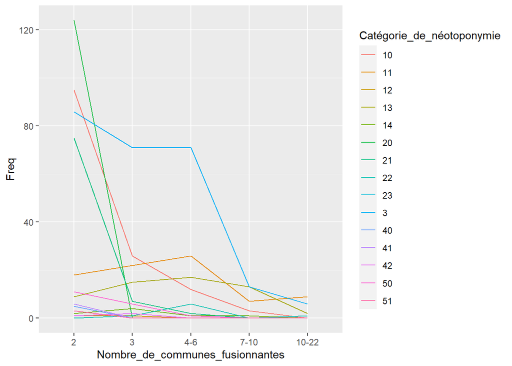

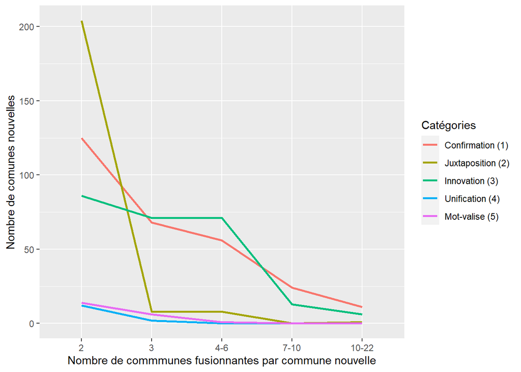

La juxtaposition paraît être la stratégie adoptée de manière préférentielle lorsque les communes fusionnantes sont peu nombreuses. En effet, d’une part il est alors envisageable d’ajouter les termes sans que le nom final ne devienne trop long (lors de la fusion de plus de deux ou trois communes, les noms deviennent rapidement impossibles à manipuler, ne serait-ce que pour les formulaires administratifs). D’autre part, lorsque le nombre de communes est relativement restreint, la commune nouvelle peut être vue comme la somme de quelques entités gardant leur identité, ce qui est moins évident avec un grand nombre de communes fusionnantes.

À l’inverse, dans le cas de fusions faisant intervenir davantage de communes, le choix paraît se porter davantage vers un nouveau nom, d’où des néotoponymes fondés sur une innovation. On se retrouve ici à l’autre bout du spectre avec, dans le cas de fusions de nombreuses communes, une volonté d’éviter l’hégémonie de l’une ou plusieurs d’entre elles et le choix, alors, d’un terme ne faisant pas explicitement référence à une ancienne commune. Un exemple assez intéressant est le cas de la commune d’Aurseulles, dans le Calvados. Cette dernière est issue de la fusion de quatre communes : Longraye, Saint-Germain-d’Ectot, Torteval-Quesnay mais surtout Anctoville, elle-même adjointe de trois communes associées (issues d’une fusion « Marcellin » en 1973, Feuguerolles, Orbois et Sarmentot) qui deviendront communes déléguées[^13]. Pour éviter la prédominance d’une commune, un nom nouveau a été créé, en concaténant les noms de deux rivières, l’Aure et la Seulles (figure 5).

**Figure 5 : Trouver un dénominateur commun : la commune nouvelle d’Aurseulles**

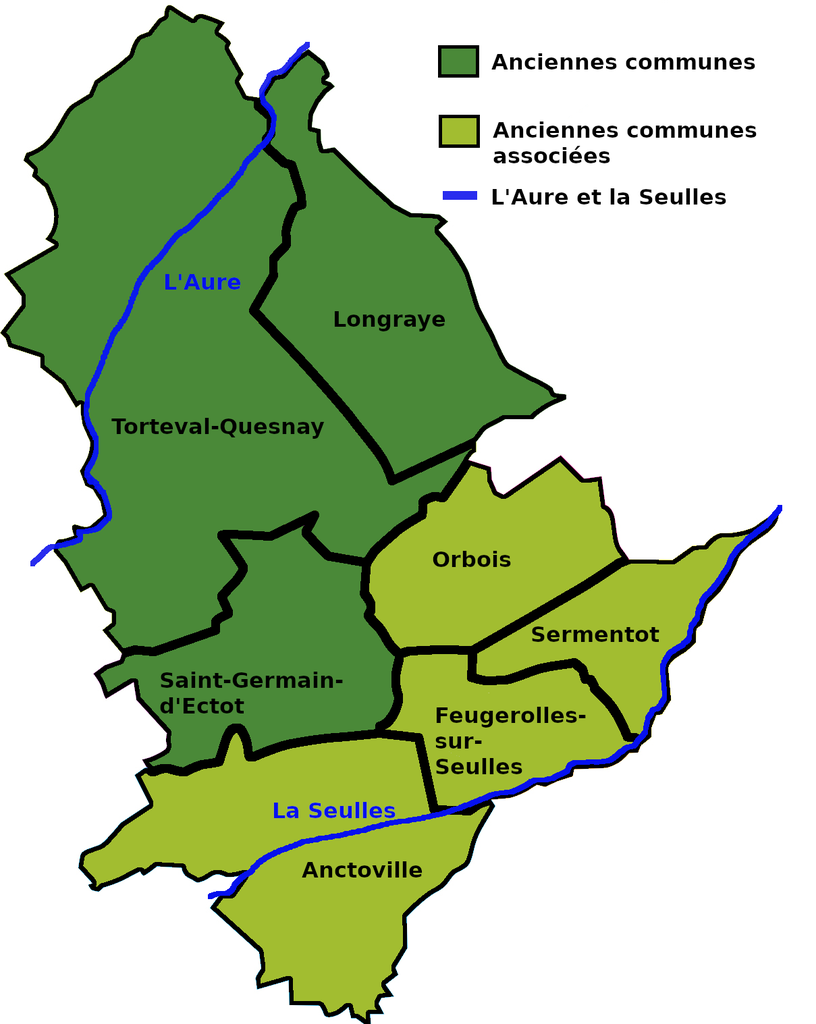

Certains types particuliers comme l’unification ou les mots-valises sont quasiment exclusivement cantonnés à des communes nouvelles ne dépassant pas trois communes fusionnantes voire liés à des occasions spécifiques ; chaque commune n’a pas forcément un presque homonyme avec qui fusionner comme Auxon-Dessous et Auxon-Dessus (Doubs).

## UN PROFIL PARTICULIÈREMENT RÉVÉLATEUR DES RAPPORTS DE FORCE : LE TYPE 1 (CONFIRMATION)

La dynamique est moins linéaire pour la Confirmation, dépendant davantage des sous-catégories avec une présence plus nette, par exemple, des confirmations avec troncatures et ajouts dans les communes nouvelles de taille assez importante (4 à 10 communes fusionnantes). Cette catégorie mérite donc une analyse plus approfondie, en particulier pour connaître les caractéristiques des communes qui imposent leur nom. De manière très large, c’est la commune chef-lieu qui donne son nom : seul le type (12) n’étant pas dans ce cas (et son effectif est très faible). On peut donc s’interroger sur le profil de la commune chef-lieu.

Quelles sont les caractéristiques de la commune qui donne son nom ?

**Tableau 3 : Les caractéristiques de la commune chef-lieu**

Les caractéristiques de la commune chef-lieu (toutes CN)

OUI

OUI (%)

NON

NON (%)

- la plus peuplée

694

88.2

93

11.8

- la plus étendue

526

66.8

261

33.2

- avec le potentiel financier le plus important (stock)

680

86.4

107

13.6

- avec le potentiel financier par habitant le plus important

465

59.1

322

40.9

Les caractéristiques de la commune chef-lieu (type 1 Confirmation)

OUI

OUI (%)

NON

NON (%)

- la plus peuplée

273

96.8

9

3.2

- la plus étendue

195

69.1

87

30.9

- avec le potentiel financier le plus important (stock)

273

96.8

9

3.2

- avec le potentiel financier par habitant le plus important

191

67.7

91

32.3

Les caractéristiques de la commune chef-lieu

Toutes communes nouvelles

Néotoponyme de type 1 (Confirmation

OUI

OUI (%)

NON

NON (%)

OUI

OUI (%)

NON

NON (%)

- la plus peuplée

694

88.2

93

11.8

273

96.8

9

3.2

- la plus étendue

526

66.8

261

33.2

195

69.1

87

30.9

- avec le potentiel financier le plus important (stock)

680

86.4

107

13.6

273

96.8

9

3.2

- avec le potentiel financier par habitant le plus important

465

59.1

322

40.9

191

67.7

91

32.3

Généralement, la commune qui donne son nom est la plus peuplée, la plus étendue et la plus riche (en données brutes non relatives), même si la différence la plus nette est bien en lien avec la démographie. Surtout, cette domination de la commune chef-lieu est plus importante que sur l’ensemble des communes nouvelles. Un néotoponyme de confirmation (ou parfois, justement, la conservation d’un toponyme pour un territoire d’une taille différente) indique bien, généralement, la domination d’une commune. On peut faire un constat similaire pour le type 22 : ce sont globalement les communes les plus importantes d’un point de vue démographique qui sont les plus représentées dans le nouveau nom. On a donc bien, dans la néotoponymie, la traduction des rapports de forces à l’occasion de la création des communes nouvelles.

## DES VARIATIONS AU PRISME DU ZONAGE EN AIRE URBAINE (ZAU)

Étant donnée l’importance de la géopolitique interne des communes nouvelles dans le choix du nom, on peut également postuler un lien avec la situation urbaine ou rurale des entités concernées. Un test de Chi² permet tout d’abord de rejeter l’hypothèse d’indépendance entre le ZAU et le type de néotoponymes des communes fusionnantes (cf. tableau 4)[^14].

**Tableau 4 : Les communes fusionnantes en fonction de leur ZAU et de leur néotoponymie** Cf. en annexes pour le détail du Zonage en Aire Urbaine.

```
##  Confirmation (1) Juxtaposition (2)    Innovation (3)   Unification (4)
##              1066               485               905                30
##    Mot-valise (5)
##                50
```

```
## 111 112 120 211 212 221 222 300 400
##  75 786 297  24  73  92  30 559 600
```

```
##      Y
## X     Confirmation (1) Juxtaposition (2) Innovation (3) Unification (4)
##   111               35                25             11               0
##   112              211               185            356              15
##   120              115                47            128               4
##   211               19                 3              2               0
##   212               31                15             25               2
##   221               61                 9             21               0
##   222               16                 3             10               0
##   300              276                95            171               4
##   400              302               103            181               5
##      Y
## X     Mot-valise (5)
##   111              4
##   112             19
##   120              3
##   211              0
##   212              0
##   221              1
##   222              1
##   300             13
##   400              9
```

[interactive chart not shown]

```
##
##  Pearson's Chi-squared test
##
## data:  tabcont
## X-squared = 181.4, df = 32, p-value < 2.2e-16
```

Si le lien est loin d’être systématique, on observe néanmoins que certains types sont bien plus présents dans certaines catégories d’espaces. Par exemple, les phénomènes d’innovation sont bien plus présents dans les pôles urbains (112, 120) que les processus de confirmation. Inversement, ce sont plutôt les confirmations qui dominent dans quasiment tous les autres espaces, dépassant les deux-tiers des cas dans les pôles secondaires (211, 221) et étant aussi majoritaires dans les espaces multipolarisés ou hors d’influence des aires urbaines (300, 400). L’étude de ces types laisse à penser que plusieurs phénomènes sont identifiables :

- les centres urbains (111, 211, 221) reconnaissent assez aisément la prédominance d’un pôle, mais préfèrent, sinon, la juxtaposition : dans certains cas une commune s’impose d’elle-même (on peut penser à Cherbourg-en-Cotentin dans la Manche ou à Annecy en Haute-Savoie), sinon l’équilibre des communes est préféré ;
- les périphéries des pôles urbains (112, 120, 212) sont réticentes face à la polarisation autour d’une commune et vont préférer avoir recours à l’innovation ; cela permet de ne pas donner, au moins dans le nom, une place plus importante à l’une ou l’autre des communes fusionnantes ou marquer le fait qu’aucune commune ne se dégage réellement ; c’est le cas de la commune Les Septvallons (Aisne), regroupant sept communes de la couronne de l’aire urbaine de Reims ou de Prée d’Anjou, dans l’aire urbaine de Château-Gonthier ;
- les communes multipolarisées ou hors d’influence des pôles urbains (300, 400) ont assez fréquemment recours à l’innovation mais dans la moitié des cas c’est plutôt une commune qui va voir son nom confirmé. Dans le cas des communes multipolarisées se retrouvant au sein d’une commune nouvelle de type « Confirmation », la commune qui va donner son nom est souvent issue d’un autre type que 300 ou 400. C’est le cas d’une des premières communes nouvelles, Thizy-les-Bourgs (Rhône) qui regroupe Bourg-de-Thizy, Marnand et Thizy (communes appartenant à un petit pôle) mais aussi deux communes multipolarisées que sont La Chapelle-de-Mardore et Mardore.

# DES CHOIX PLUS FRÉQUEMMENT À LA RECHERCHE DE CONSENSUS ET DE NEUTRALITÉ QUE DE MOBILISATION IDENTITAIRE

Nous avons pu voir que la première tendance était des néotoponymes faisant référence à une commune dominant l’ensemble territorial. Face à cela, un certain nombre de stratégies ont pu être développées pour éviter un déséquilibre dans les références aux anciennes communes. Ces stratégies se retrouvent en particulier dans les différents types faisant intervenir de l’innovation. Il s’agit, évidemment, du type 3 mais également des cas où l’ajout d’un terme nouveau permet de tempérer une éventuelle hégémonie symbolique.

Ces ajouts sont la principale raison d’un allongement des noms des communes à la suite du passage en commune nouvelle. Elles ont eu tendance à faire augmenter la taille du nom des communes. Cependant, ce n’est pas quelque chose de systématique, comme nous le montre le tableau ci-dessous.

**Tableau 5 : L’évolution de la longueur des noms des communes**

|  | Min. | 1st Qu. | Median | Mean | 3rd Qu. | Max. |
| --- | --- | --- | --- | --- | --- | --- |
| Nom avant fusion (A) | 2 | 8 | 11 | 12.860410 | 18 | 44 |
| Nom après fusion (B) | 4 | 12 | 16 | 16.038249 | 20 | 40 |
| Différence (A-B) | -30 | -2 | 4 | 3.177839 | 9 | 29 |

La grande diversité des toponymes du type « Innovation » nous a poussé à préciser, pour chaque commune concernée, le type d’innovation qui était utilisée. Il s’est donc agit, en complément de la première typologie construite en fonction des régularités, de se concentrer davantage sur le sens des éléments de la néotoponymie. Cette catégorisation a été faite pour tous les thèmes faisant intervenir de l’innovation, à savoir 11, 13, 23, 3, 42 et 51[^15].

**Tableau 6 : Les innovations dans les noms des communes nouvelles**

Les innovations dans les noms des communes nouvelles

| Type d’innovation | Nombre de communes nouvelles concernées | Pourcentage en fonction du nombre d’innovations | Pourcentage en fonction du nombre de communes nouvelles ayant innové | Pourcentage en fonction du nombre de communes nouvelles | Explication du type |
| --- | --- | --- | --- | --- | --- |
| Paysage | 153 | 42.15 | 38.64 | 19.44 | Noms communs tels que : Val, Vallée, Pays, Terres, le-Lac, sur Mer, Porte de. |
| Eau | 149 | 41.05 | 37.63 | 18.93 | Nom propre de fleuve, rivière, éventuellement lac. |
| Région | 108 | 29.75 | 27.27 | 13.72 | Utilisation du nom d’une région (ou d’un ensemble régional) nettement plus vaste que la commune nouvelle. Par exemple le Bugey ou Anjou va être considéré comme une région alors que Haut-Valromey va êt… |
| Invention | 38 | 10.47 | 9.6 | 4.83 | Quand le terme est complètement inventé, qu’il n’est pas un toponyme déjà utilisé pour une autre entité spatiale. Ex. : Valambray, « Val, racine de Val-ès-Dunes, la communauté de communes ; ambre pour… |
| Relief | 35 | 9.64 | 8.84 | 4.45 | Utilisation d’un nom propre faisant référence à un relief (sommet , massif, gorges, forêts éventuellement). |
| Patrimoine | 29 | 7.99 | 7.32 | 3.68 | Utilisation d’un terme faisant référence au patrimoine, plutôt historique type Formigny La Bataille ou patrimoine culturel, voire ancien nom. |
| Promotion | 12 | 3.31 | 3.03 | 1.52 | Mise en avant d’un toponyme existant, faisant référence à un lieu plus restreint (par exemple un hameau à la limite des communes fusionnantes). |
| Village | 12 | 3.31 | 3.03 | 1.52 | Utilisation du terme « Village », au singulier ou au pluriel. |
| Équipement | 9 | 2.48 | 2.27 | 1.14 | Noms propres : type La Hague, Aime-La Plagne. |
| Banalité | 7 | 1.93 | 1.77 | 0.89 | Ajout d’un terme faisant référence à une banalité. Exemples : moulins, ponts. |
| Commune nouvelle | 6 | 1.65 | 1.52 | 0.76 | Utilisation du terme de « Commune nouvelle » ou seulement « Nouvelle ». |
| R° | 6 | 1.65 | 1.52 | 0.76 | Régionalisation du nom (Malesherbois par exemple). |
| Bocage | 5 | 1.38 | 1.26 | 0.64 | Utilisation du terme de « Bocage ». |
| Grand | 4 | 1.1 | 1.01 | 0.51 | Utilisation du terme « Grand ». |
| TOTAL | 573 | 157.86 | 144.71 |  | TOTAL |

Ces données permettent de mettre en avant de très fréquentes références aux éléments paysagers en général. Il peut s’agir de références à des ensembles assez vagues (Porte, Pays) ou à des éléments hydrographiques en particulier, phénomènes qui ont déjà été pointés dans des évolutions communales plus anciennes (Guerrin 1998a) ou dans la dénomination d’autres échelles territoriales françaises (Brunet 2015 ; Ozouf-Marignier 1988).

Une mention particulière doit être faite au sujet des vals et vallées, très nombreux, qui non seulement participent d’un passage plus général au topographique depuis une couche toponymique initiale de localités et qui participent également d’un engouement marketing pour le référent américain de la *valley* qui compte nombre de « success story » au premier rang desquelles la Silicon Valley ou en France et dans un autre registre la Biovallée dromoise.

Les éléments les plus importants sont ensuite de l’ordre du commun : termes paysagers assez usuels ou non spécifiques au territoire concerné (Villages, Commune nouvelle, Bocage…). La prise en compte de l’ensemble de ces éléments révèle souvent une faible profondeur historique ou d’identification à ces toponymes. Plutôt qu’un élément patrimonial réellement unificateur, il apparaît que les préférences sont souvent allées à des termes assez génériques et consensuels, pour ne pas dire lisses. De nombreux exemples ont été collectés avec gourmandise (Brunet 2021), on n’en citera que deux : Brie, Oiron, Saint-Jouin-de-Marnes et Taié-Maulais qui ont fusionné en « Plaine-et-Vallées » (Deux-Sèvres) tandis que Soucelles et Villevêque sont devenues « Rives-du-Loir-en-Anjou » (Maine-et-Loire), le nom permettant à lui seul de situer la commune sur une carte. Deux raisons peuvent être envisagées pour expliquer ces toponymes très descriptifs. D’une part, la question de la rapidité du choix est importante, concernant parfois des communes avec des ressources peu développées (pas de personnel dédié à la communication ou pouvant effectuer des recherches archivistiques, nous l’avons dit). D’autre part, les communes nouvelles ont souvent été présentées comme des « mariages de raison », sans qu’il n’y ait systématiquement un lien évident et surtout exclusif entre les communes fusionnantes. Par conséquent, la recherche de dénominateurs communs s’est souvent orientée vers des éléments paysagers partagés entre les participants.

Deux types d’innovations font eux davantage référence à un élément très spécifique aux communes fusionnantes : c’est le cas des équipements et de références à un patrimoine commun. Ces situations se sont révélées relativement peu fréquentes : seules 38 communes nouvelles l’ont utilisé, représentant 170 communes fusionnantes. Dans cette catégorie sont présents des toponymes d’une renommée variable : de La Hague à Courchevel, en passant par Souleuvre que le site de la commune de Souleuvre-en-Bocage (Calvados) présente comme « la base européenne de saut à l’élastique, dont la renommée dépasse désormais largement les frontières du département du Calvados » ([Souleuvreenbocage.fr](https://www.souleuvreenbocage.fr/souleuvre-en-bocage/)). Des références très variables sont également mobilisées : du nom d’un canal comme Aubessagne (Hautes-Alpes) à la référence à une ancienne voie romaine à Beauce la Romaine (Loir-et-Cher) en passant par le nom d’un ancien saint patron à Saint Martin de l’If (Seine-Maritime). Dans le cas d’Autrans-Méaudre en Vercors (Isère), il y a mobilisation d’un terme associé à la Résistance, en diffusant un nom utilisé de manière plus restreinte auparavant mais à la connotation largement valorisante. Dans plusieurs des cas où une référence patrimoniale a été choisie, les archives ont été consultées pour retrouver d’anciens toponymes (anciens noms de la commune par exemple) ou un passé commun (La Baronnie, dans l’Eure, constituée de communes ayant appartenu à une même baronnie aux XIIIe-XVe siècles).

La comparaison de la présence de certains motifs avant ou après la fusion (tableau 7) nous donne encore d’autres éléments concernant les ajouts. Il s’agit d’observer les évolutions qui pourraient être notables avec l’apparition ou la disparition de certaines références.

**Tableau 7 : Étude de quelques motifs avant et après fusion**[^16].

Étude de quelques motifs avant et après fusion

| Motif testé | Communes non fusionnantes Nombre | Communes non fusionnantes Pourcentage | Communes fusionnantes (nom initial) Nombre | Communes fusionnantes (nom initial) Pourcentage | Communes fusionnantes (nom choisi) Nombre | Communes fusionnantes (nom choisi) Pourcentage | Communes nouvelles (nom choisi) Nombre | Communes nouvelles (nom choisi) Pourcentage | Communes nouvelles ayant innové Nombre | Communes nouvelles ayant innové Pourcentage | Nombre de communes l’ayant : conservé | Nombre de communes l’ayant : perdu | Nombre de communes l’ayant : gagné | Exemples de noms de communes nouvelles |
| --- | --- | --- | --- | --- | --- | --- | --- | --- | --- | --- | --- | --- | --- | --- |
| Saint | 4344 | 12.9 % | 420 | 16.56 % | 202 | 7.97 % | 78 | 9.91 % | 4 | 1.01 % | 90 | 330 | 112 | Saint Geniez d’Olt et d’Aubrac, Saint-Pierre-en-Auge, Saint-Pierre-La-Noue, Saint Privat en Périgord, Saint-Jean-de-Galaure |
| Val | 309 | 0.92 % | 25 | 0.99 % | 326 | 12.85 % | 93 | 11.82 % | 84 | 21.21 % | 11 | 14 | 315 | Valserhône, Valromey-sur-Séran, Bresse Vallons, Haut Valromey, Val-Revermont |
| Porte | 16 | 0.05 % | 1 | 0.04 % | 24 | 0.95 % | 9 | 1.14 % | 8 | 2.02 % | 1 | 0 | 23 | Porte-de-Benauge, Les Portes du Coglais, Porte-des-Bonnevaux, Porte-du-Quercy, La Porte du Der |
| Pays | 1 | 0 % | 0 | 0 % | 27 | 1.06 % | 3 | 0.38 % | 3 | 0.76 % | 0 | 0 | 27 | Livarot-Pays-d’Auge, Pays de Belvès, Pays-de-Clerval |
| Mont | 993 | 2.95 % | 82 | 3.23 % | 112 | 4.42 % | 33 | 4.19 % | 12 | 3.03 % | 28 | 54 | 84 | Les Monts d’Aunay, Montillières-sur-Orne, Montaignac-sur-Doustre, Les Monts du Roumois, Valzin en Petite Montagne |
| nouvelle | 1 | 0 % | 0 | 0 % | 8 | 0.32 % | 2 | 0.25 % | 2 | 0.51 % | 0 | 0 | 8 | Jugon-les-Lacs - Commune nouvelle, Commune nouvelle d’Arrou |
| Nouvelle | 3 | 0.01 % | 0 | 0 % | 8 | 0.32 % | 2 | 0.25 % | 2 | 0.51 % | 0 | 0 | 8 | Morcenx-la-Nouvelle, Oucques La Nouvelle |

On remarque, sur ces motifs, la croissance importante de référence à des reliefs (Val, Mont), montrant encore une fois le fort recours à des éléments de description, mais qui permettent aussi d’englober des communes considérant appartenir à un même ensemble régional sans pour autant avoir de dénomination spécifique. On est bien ici dans une logique de banalisation et d’uniformisation, voire de neutralisation, plutôt que d’une valorisation fréquente d’un bonus identitaire évident.

Concernant la disparition de mots issus de langues régionales, le cas de la Bretagne a été pointé dans certains articles de presse ou blogs régionaux (Bourgès samedi 7 janvier 2017 ; Larvor 2017). Dans les faits, cette crainte, fondée principalement sur un cas (Brignogan-Plage et Plounéour-Trez ayant fusionné en Plounéour-Brignogan-plages, faisant disparaître la traduction bretonne de « plage »), ne paraît pas se retrouver dans de nombreuses autres situations. Certaines communes nouvelles viennent même s’inscrire en faux avec le choix d’une dénomination construite à partir de termes issus de langues régionales. On peut prendre pour exemple la commune de Maen-Roch (Ille-et-Vilaine, fusion de Saint-Brice-en-Coglès et Saint-Étienne-en-Coglès). Ce choix est intéressant à plus d’un titre : tout d’abord, car il s’est fait en plusieurs étapes avec la possibilité pour les habitants de proposer des noms, puis une commission d’élus a sélectionné six noms, qui ont été d’abord soumis aux conseils municipaux, les trois noms ayant emporté le scrutin ont, enfin, été soumis pour consultation aux habitants (le nom arrivé en tête aux conseils municipaux a été le même chez les habitants). On retrouve donc les différentes étapes que nous évoquions plus haut. Ensuite, les trois choix proposés finalement vont, de fait, à l’encontre des recommandations de la Commission Nationale de Toponymie, à savoir : Hauts-de-Bretagne (Maen-Roch se situe proche de la Normandie, soit dans la région dite de « Haute Bretagne », mais sans la dominer), Coglance (contraction de deux noms de rivières, Coglès et Loisance, ce nom n’a donc pas de signification propre) et Maen-Roch, qui est bien dans la logique descriptive mais sans historicité et avec une redondance puisque Maen signifie « pierre » en breton et Roch signifie « roche » en gallo (langue romane présente dans la moitié ouest de la Bretagne). Ainsi, au vu des données concernant les communes nouvelles en Bretagne, il paraît abusif de considérer que ce mouvement aurait une tendance profonde à faire disparaître les toponymes bretons.

Dans d’autres contextes également, les langues régionales ont été utilisées pour décrire les paysages. Par exemple, en Lozère, la commune de Cans et Cévennes a bâti son nom à partir de la référence à la région et au terme « cans » signifiant « petite montagne », ou encore la commune de Illtal (Haut-Rhin), construite à partir du nom d’un cours d’eau et de « tal » signifiant « vallée » en alémanique.

# CONCLUSION : LES SPÉCIFICITÉS DES NOMS DES COMMUNES NOUVELLES FRANÇAISES

Pour mettre en perspective les spécificités de la néotoponymie des communes nouvelles, il est possible de s’appuyer sur les études de contextes similaires. Concernant les changements de noms de communes françaises avant 2007 (changement de nom généralement sans changement de périmètre), le bilan montrait des transformations souvent axées sur des enjeux économiques, voire marketing et stratégiques, en tant que signaux envoyés, vecteurs de communication vers l’extérieur (Delattre 2007). À propos des espaces de coopération intercommunale, l’étude des noms des EPCI a mis en exergue des choix de noms qui pourraient être un atout de visibilité voire de performance économique (Bailly 2008), constat repris également pour le nom des pôles d’excellence rurale dans les années 2000 au service de l’émergence d’« un mode de développement patrimonial, qui mobilise des ressources territoriales spécifiques » (Landel and Senil 2008). En revanche, l’étude des nouveaux noms de cantons français montrait des choix souvent fondés sur des rivières, des éléments de reliefs voire des noms purement descriptifs et anonymes à partir de noms communs (Brunet 2015). Dans le cadre des communes fusionnées en Suisse, les cantons ayant été souvent assez directifs dans leurs consignes de choix de nom, « moins d’un toponyme sur cinq est un toponyme communal véritablement nouveau. » (Destrem and Métronom 2016) avec une « archi-domination » du phénomène de confirmation et, en fonction des régions, des cas de référence au patrimoine naturel ou une tendance à la juxtaposition dans le cas de la fusion de deux communes.

Cette comparaison tendrait à montrer que les néotoponymes des communes nouvelles se rapprocheraient considérablement des néotoponymes d’autres territoires fusionnant : tendance à la confirmation et à la juxtaposition comme les communes fusionnantes en Suisse ainsi que tendance aux innovations reprenant des éléments généralement descriptifs, hydrographiques ou liés au relief comme les cantons français. Cette dernière tendance, non majoritaire mais importante, a pour conséquence de tirer la couche toponymique municipale des références exclusives aux localités vers des références à des entités topographiques, paysagères et territoriales, parfois génériques et désincarnées. En revanche, le nom a moins été utilisé comme vecteur de visibilité et d’atout économique que ce qui a pu être relevé par exemple pour les pôles d’excellence rurale ou les intercommunalités urbaines, si ce n’est par la revendication de lieu d’accès à des ressources régionales.

Alors que ce mouvement paraît promettre de se poursuivre (Bideau 2020), cette première étude des nouveaux noms permet de mettre en avant la diversité des pratiques toponymiques des communes nouvelles, certaines s’organisant symboliquement autour d’une commune qui devient alors bien plus visible, tandis que d’autres s’orientent davantage vers inscription dans une aire s’apparentant à un territoire mais paradoxalement plus neutre du point de vue de l’identité territoriale. La question qui se pose est alors l’appropriation de cette nouvelle entité par les habitants, ce qui pourrait faire l’objet d’études de terrains spécifiques, après désormais plusieurs années d’existence pour une grande partie des communes nouvelles.

# ANNEXES

## Le Zonage en Aires Urbaines

Source : INSEE

Catégorie de la commune dans le zonage en aires urbaines 2010 Ce code indique la catégorie de la commune au sein du découpage en aires urbaines.

Modalités :

111 : Commune appartenant à un grand pôle (10 000 emplois ou plus) 112 : Commune appartenant à la couronne d’un grand pôle 120 : Commune multipolarisée des grandes aires urbaines 211 : Commune appartenant à un moyen pôle (5 000 à moins de 10 000 emplois) 212 : Commune appartenant à la couronne d’un moyen pôle 221 : Commune appartenant à un petit pôle (de 1 500 à moins de 5 000 emplois) 222 : Commune appartenant à la couronne d’un petit pôle 300 : Autre commune multipolarisée 400 : Commune isolée hors influence des pôles

L’espace des grandes aires urbaines est composé des communes dont la modalité vaut 111, 112, ou 120. L’espace des autres aires urbaines et composé des communes dont la modalité vaut 211, 212, 221 ou 222.

Par ailleurs, l’espace péri-urbain est composé des communes dont la modalité vaut 112 ou 120.

## Étude manuelle des “en,” “de” etc

Quels sont les noms de communes nouvelles ou fusionnantes qui ont la forme d’un nom associé à celui d’un pays, d’une région ou d’une ancienne province par les prépositions : en, au, de ou du… ? Compte formes régionalisations : en négligeant les noms communs (par exemple Valzin en Petite Montagne) et les “sur” un fleuve. Prise en compte des “Normandie” par exemple mais pas des “Malesherbois.” Des “sur Vendée” et des “en Seine” mais pas des “sur Seine.” On laisse aussi de côté les petits Saints… Importance de certaines références : Périgord, Ouche, Mauges, Quercy (5 communes nouvelles), Anjou (11 communes nouvelles) etc. Que faire des Sables d’Olonne et de Saint-Germain-en-Laye ?

## Autres approches possibles à partir de données complémentaires : Néotoponymie et typologie

Une typologie exploratoire des communes fusionnantes a été réalisée (Bideau and Ysebaert (\`A para\^itre), « Les communes nouvelles françaises (2010-2020) : quels profils pour ces territoires du quotidien remaniés ? », *L’Espace géographique*, tome 50, n°1, 2021-2022), aboutissant à cinq types, basés sur des critères socio-économiques (principalement classes d’âges, secteur d’emploi, taux de navetteurs). C’est celle-ci qui est utilisée ici.

```
##  Confirmation (1) Juxtaposition (2)    Innovation (3)   Unification (4)
##              1059               478               900                28
##    Mot-valise (5)
##                50
```

```
##    Length     Class      Mode
##      2515 character character
```

```
##                 Y
## X                Confirmation (1) Juxtaposition (2) Innovation (3)
##   Groupe 1 PPCQ               393               151            239
##   Groupe 2 PFO                263               168            346
##   Groupe 3 MOARO              104                42             84
##   Groupe 4 VAR                179                66            162
##   Groupe 5 REAV               120                51             69
##                 Y
## X                Unification (4) Mot-valise (5)
##   Groupe 1 PPCQ               12             14
##   Groupe 2 PFO                11             21
##   Groupe 3 MOARO               0              3
##   Groupe 4 VAR                 3              8
##   Groupe 5 REAV                2              4
```

```
##
##  Pearson's Chi-squared test
##
## data:  tabcont
## X-squared = 65.222, df = 16, p-value = 6.746e-08
```

On peut donc rejeter l’hypothèse d’indépendance entre des variables socio-économiques et la néotoponymie. Notre hypothèse est que le lien statistique qu’on aperçoit est le lien entre néotoponymie et situation vis-à-vis des polarisations urbaines (cf. ZAU).

## Addendum concernant quelques exemples récents

Dernière mise à jour : mars 2022.

Nous pouvons noter, dans l’actualité récente, quelques cas assez intéressants concernant la néotoponymie des communes nouvelles.

### Retours en arrière ?

Un cas de changement de nom, où la commune nouvelle a repris le nom de la commune chef-lieu.

Au 1<sup>er</sup> janvier 2016, Thaon-les-Vosges, Girmont et Oncourt avaient fusionné pour créer une commune nouvelle nommée, dans une logique assez marketing “Capavenir Vosges.” En novembre 2020, un sondage auprès des habitants avaient confirmé le choix majoritaire de revenir au nom de Thaon-les-Vosges (le détail des résultats, par exemple en fonction des différentes communes déléguées n’a pas été publié). En décembre 2021, la commune a reçu l’autorisation officielle de reprendre le nom de l’ancienne commune qui était devenue chef-lieu. Cf. par exemple ici.

Et un autre cas où, après la fusion, un sondage consultatif a été lancé en octobre 2021 auprès des habitants pour savoir s’ils voulaient changer de nom dans la commune de Moult-Chicheboville (fusion au 1<sup>er</sup> janvie 2017), cf. [ici](https://www.ouest-france.fr/normandie/moult-chicheboville-14370/polemique-sur-un-eventuel-changement-de-nom-de-la-commune-de-moult-chicheboville-fdc702a4-38b3-11ec-a369-eeb958b0e1c8).

Cette consultation faisait suite à une promesse électorale de questionner la population, même si l’opposition et la maire de la commune sont défavorables au changement de nom. Le 12 janvier 2022, les résultats ont été publiés sur le [site de la mairie](https://www.mairie-moult.fr/?page_id=8627) : « Contre le changement de nom : 363 Pour le changement de nom : 36 Par conséquent, le nom de la commune restera Moult-Chicheboville. Nous procéderons prochainement au changement des panneaux d’entrée d’agglomération. ». La population de la commune nouvelle est d’un peu plus de 3000 habitants.

### Des références multiples

Un cas de référence à des éléments orographiques mais aussi littéraires : Pechs-de-l’Espérance

Cette commune nouvelle, issue de la fusion de Peyrillac-et-Millac, Cazoulès et Orliaguet au 1<sup>er</sup> janvier 2022, a des références multiples. Certes, elle prend son nom d’un cours d’eau et fait référence au relief (pech signifie puy en occitan) mais il y a également une référence plus littéraire. « Elle [cette appellation] est la plus appropriée, car elle met à la fois en valeur la topographie et la toponymie locale [NDLR: le pech est un mot occitan désignant un puy] et fait une allusion poétique au célèbre roman de l’écrivain Christian Signol, “La Rivière Espérance” pour citer la rivière Dordogne. ». Source [ici](https://www.sudouest.fr/dordogne/peyrillac-et-millac/dordogne-cazoules-orliaguet-et-peyrillac-et-millac-ont-choisi-leur-nouveau-nom-6006964.php).

### Le choix des gentilés

Des questions peuvent se poser concernant le choix des gentilés. C’est par exemple le cas dans la commune de Lamballe-Armor (commune nouvelle constituée en deux fois, aux 1<sup>er</sup> janvier 2016 puis 2019, de Lamballe, Meslin, Morieux et Planguenoual), où une consultation visait à trouver un gentilé pour la commune nouvelle mais certains gentilés plébiscités (avec certes seulement quelques dizaines de voix pour quelques milliers d’habitants pour la commune nouvelle) sont des gentilés des anciennes communes, comme les Lamballais.

Au moins trois articles dans la presse régionale sur le sujet entre mars et décembre 2021 : [ici](https://www.letelegramme.fr/cotes-darmor/lamballe-armor/les-habitants-de-lamballe-armor-des-propositions-de-nom-emergent-26-03-2021-12725181.php), [là](https://www.letelegramme.fr/cotes-darmor/lamballe-armor/lamballe-armor-qu-est-ce-qu-il-n-a-pas-plu-dans-les-votes-en-ligne-des-habitants-26-12-2021-12895899.php) et enfin [là](https://www.letelegramme.fr/cotes-darmor/lamballe-armor/futur-nom-des-habitants-de-lamballe-armor-precisions-de-la-ville-28-12-2021-12896789.php).

### Des problèmes d’adressage et de repérage

Plusieurs articles de la presse régionale se sont fait l’écho de difficultés pour faire parvenir les courriers voire pour que les secours puissent arriver sur place.

En particulier cet article évoquant le nom de la commune nouvelle sur les panneaux : « Mais c’est à y perdre son latin, car Plaine-et-Vallées n’est pas une agglomération, pas plus qu’un bourg ou un village. C’est une appellation virtuelle, ou plus précisément une dénomination purement administrative. » Source [ici](https://www.lanouvellerepublique.fr/thouars/insolite-pres-de-thouars-et-dans-les-deux-sevres-mais-ou-est-donc-passe-oiron).

# BIBLIOGRAPHIE

Amilhat Szary, Anne-Laure. 2008. “Des territoires sans nom peuvent-ils être sans qualité ? Réflexions sur les modifications de la carte administrative chilienne.” *L’Espace Politique. Revue en ligne de géographie politique et de géopolitique*, no. 5 (December). https://doi.org/10.4000/espacepolitique.327.

Antheaume, Benoît, and Frédéric Giraut, eds. 2005, cop. 2005. *Le territoire est mort, vive les territoires !: une (re)fabrication au nom du développement*. Paris, France: IRD éd., 2005.

Aubelle, Vincent. 2016. *Les Communes Nouvelles*. Edited by Pascale Gibert and Jacques Pélissard. 2ème édition. Les Indispensables. Paris: Berger-Levrault.

Bailly, Guillaume. 2008. “Nommer les espaces de coopération intercommunale.” *L’Espace Politique. Revue en ligne de géographie politique et de géopolitique*, no. 5 (December). https://doi.org/10.4000/espacepolitique.317.

Barlow, Max, and Doris Wastl-Walter, eds. 2004. *New Challenges in Local and Regional Administration*. Ashgate.

Bideau, Gabriel. 2019. “Les communes nouvelles françaises (2010-2019) : Une réforme territoriale silencieuse.” *Annales de Géographie* 728 (4/2019): 57–85.

———. 2020. “Loi de 2019 sur les communes nouvelles en France : quelles conséquences pour les territoires ?” {Actualit\'e}. *Géoconfluences*. http://geoconfluences.ens-lyon.fr/actualites/eclairage/loi-communes-nouvelles.

Bideau, Gabriel, and Ronan Ysebaert. \`A para\^itre. “Les Communes Nouvelles Françaises (2010-2020) : Quels Profils Pour Ces Territoires Du Quotidien Remaniés ?” *L’Espace géographique* 50 (1).

Bigon, Liora, ed. 2016. *Place Names in Africa: Colonial Urban Legacies, Entangled Histories*. Springer International Publishing. https://doi.org/10.1007/978-3-319-32485-2.

———. 2020. “Towards Creating a Global Urban ToponymyA Comment.” *Urban Science* 4 (4): 75. https://doi.org/10.3390/urbansci4040075.

Bourgès, André-Yves. samedi 7 janvier 2017. “Les Communes Nouvelles Et La néo-Toponymie En Bretagne : Le Cas Du Coglais.” *Variétés Historiques*.

Brenner, Neil. 2004. *New State Spaces: Urban Governance and the Rescaling of Statehood*. Oxford: Oxford University Press. https://doi.org/10.1093/acprof:oso/9780199270057.001.0001.

Brunet, Roger. 2015. “Nouveaux cantons en France : jeux de noms.” *L’Espace géographique* 44 (1): 73–80. https://doi.org/10.3917/eg.441.0073.

———. 2021. *Nouveaux territoires, nouveaux noms de la France*. Paris, France: Hermann.

Cardoso, Rodrigo V, and Evert J Meijers. 2017. “The Metropolitan Name Game: The Pathways to Place Naming Shaping Metropolitan Regions.” *Environment and Planning A* 49 (3): 703–21. https://doi.org/10.1177/0308518X16678851.

Chamboredon, Jean-Claude. 1988. “Carte, désignations territoriales, sens commun géographique : les "noms de pays" selon Lucien Gallois.” *Études rurales* 109 (1): 5–54. https://doi.org/10.3406/rural.1988.3221.

Collignon, Béatrice. 1996. *Les Inuits : Ce Qu’ils Savent Du Territoire*. Paris: L’Harmattan.

Deas, Iain, and Alex Lord. 2006. “From a New Regionalism to an Unusual Regionalism? The Emergence of Non-standard Regional Spaces and Lessons for the Territorial Reorganisation of the State.” *Urban Studies* 43 (10): 1847–77. https://doi.org/10.1080/00420980600838143.

Delattre, Eric. 2007. “Le changement de nom des communes françaises aspects économiques, marketing et stratégiques, Renaming the French communes economic, marketing and strategic aspects.” *Revue d’Économie Régionale & Urbaine* juillet (2): 269–91. https://doi.org/10.3917/reru.072.0269.

Destrem, Lucas, and Groupe Métronom. 2016. “Un état des lieux des noms de communes fusionnées en Suisse.” {Billet}. *NEOTOPONYMIE/NEOTOPONYMY*.

Eades, Gwilym Lucas. 2016. *The Geography of Names. Indigenous to Post-Foundational*. Londres: Routledge.

Edelblutte, Simon. 2000. “Réflexion sur les modifications du maillage communal francais depuis 1790.” *Revue Géographique de l’Est* 40 (4).

Escudié, Jean-Noël, and P2C. 2021. “Changement de nom des communes : l’Intérieur fixe des limites.” *Banque des Territoires, Localtis*. https://www.banquedesterritoires.fr/changement-de-nom-des-communes-linterieur-fixe-des-limites.

Estèbe, Philippe. 2008. *Gouverner la ville mobile: intercommunalité et démocratie locale*. Paris, France: Presses universitaires de France.

Frinault, Thomas. 2017. “Les communes nouvelles : l’invité surprise de la réforme territoriale, New municipalities: the unexpected guest of the local territorial reform.” *Revue française d’administration publique*, no. 162 (November): 277–94. https://doi.org/10.3917/rfap.162.0277.

Gerbaux, Françoise, ed. 1999. *Utopie Pour Le Territoire : Cohérence Ou Complexité ?* La Tour d’Aigues: Éditions de l’Aube.

Giraut, Frédéric. 2002. “L’exception territoriale française sous influence européenne ? Resituer la dynamique du système français d’administration territoriale.” *L’information géographique* 66 (2): 133–61. https://doi.org/10.3406/ingeo.2002.2802.

———. 2005. “Fabriquer Des Territoires. Utopies, Modèles Et Projets.” Habilitation \`a Diriger Des Recherches, Université de Paris I.

———. 2016. “Nouveaux noms de régions françaises et marketing territorial, ou quand le grand, le haut et le nouveau ratent ce que l’Occitan réussit.” {Billet}. *NEOTOPONYMIE/NEOTOPONYMY*.

———. 2020. “Dénominations plurielles : quand les noms de lieux se concurrencent !” *EchoGéo*, no. 53 (October). https://doi.org/10.4000/echogeo.20167.

Giraut, Frédéric, Sylvain Guyot, and Myriam Houssay-Holzschuch. 2008. “Enjeux de mots: les changements toponymiques sud-africains.” *Espace Geographique* 2008 (2): 131.

Giraut, Frédéric, and Myriam Houssay-Holzschuch, eds. 2021. *Nommer Le Monde : La dénomination Des Lieux*. ISTE. Londres.

Giraut, Frédéric, and Romain Lajarge. 1996. “Les Pays-Tests , Quelles Configurations Pour Quels Projets ?” *Montagnes Méditerranéennes* 3: 19–27.

Guerrin, Christian. 1998a. “Thèse : Christian Guerrin : Étude socio-toponymique de la variation dans les noms de communes françaises entre 1943 et 1996.” *Nouvelle revue d’onomastique* 31 (1): 343–44.

———. 1998b. *Etude Socio-Toponymique de La Variation Dans Les Noms de Communes Françaises Entre 1943 Et 1996*. Rouen.

———. 2000. “Les compléments toponymiques dans les noms de communes de Seine-Maritime.” *Nouvelle revue d’onomastique* 35 (1): 307–22. https://doi.org/10.3406/onoma.2000.1378.

Guichard, Olivier. 1976. *Vivre ensemble: rapport de la Commission de développement des responsabilités locales*. Paris, France: la Documentation française.

Guo, Jing, and Zhengyu Zhang. 2019. “Does Renaming Promote Economic Development? New Evidence from a City-Renaming Reform Experiment in China.” *China Economic Review* 57 (October): 101344. https://doi.org/10.1016/j.chieco.2019.101344.

Ji, Xiaomei. 2017. “City-Renaming and Its Effects in China.” *GeoJournal*, May, 1–17. https://doi.org/10.1007/s10708-017-9772-0.

Kada, Nicolas. 2017. “Les communes nouvelles , vous avez dit nouvelles ?, Are ‘new municipalities’ really new?” *Revue française d’administration publique*, no. 162 (November): 267–76. https://doi.org/10.3917/rfap.162.0267.

Karlander, David. 2017. “Roads to Regimentation: Place, Authenticity and the Metapragmatics of Naming.” *Language & Communication* 53 (January): 11–24. https://doi.org/10.1016/j.langcom.2016.11.002.

Lajarge, Romain. 2002. “Territoires au pluriel : projets et acteurs en recompositions.” *L’information géographique* 66 (2): 113–32. https://doi.org/10.3406/ingeo.2002.2801.

Landel, Pierre-Antoine, and Nicolas Senil. 2008. “Les nouveaux territoires et leurs noms entre projet et compétitivité : le cas des ‘pôles d’excellence rurale’.” *L’Espace Politique. Revue en ligne de géographie politique et de géopolitique*, no. 5 (December). https://doi.org/10.4000/espacepolitique.270.

Larvor, Ronan. 2017. “Toponymie Bretonne. Un Trésor En Danger...” *Le Télégramme*. http://www.letelegramme.fr/bretagne/toponymie-bretonne-un-tresor-en-danger-12-09-2017-11659329.php.

Lenfant, Thibaut. 2018. “La commune nouvelle, enjeux et perspectives d’un nouveau régime de fusion des communes.” {Th\`ese de doctorat (droit public)}, Paris: Université Paris 1 Panthéon-Sorbonne.

Léonard, Carol. 2010. “D’une hagionymie abondante à une hiéronymie supplétive. Usage d’une stratégie toponymique chez les Franco-Canadiens de la Saskatchewan.” *Cahiers de géographie du Québec* 54 (151): 25–40. https://doi.org/10.7202/044365ar.

Light, Duncan, and Craig Young. 2015. “Toponymy as Commodity: Exploring the Economic Dimensions of Urban Place Names.” *International Journal of Urban and Regional Research* 39 (3): 435–50. https://doi.org/10.1111/1468-2427.12153.

Lu, Shengfeng, Yiping Wu, and Xiao Xie. 2018. “Benefit of Historical Reputation: Evidence from the City Renaming Reforms in China.” *China Economic Quarterly* 17(3) (April): 1055–78.

Medway, Dominic, and Gary Warnaby. 2014. “What’s in a Name? Place Branding and Toponymic Commodification.” *Environment and Planning A: Economy and Space* 46 (1): 153–67. https://doi.org/10.1068/a45571.

Meligrana, John, ed. 2004. *Redrawing local government boundaries: an international study of politics, procedures and decisions*. Vancouver, Canada: UBC Press.

Offner, Jean-Marc. 2006. “Les territoires de l’action publique locale.” *Revue française de science politique* Vol. 56 (1): 27–47.

Ozouf-Marignier, Marie-Vic. 1988. *La formation des départements: la représentation du territoire français à la fin du 18e siècle*. Paris, France: Éditions de l’École des hautes études en sciences sociales.

Pasquier, Romain. 2017. “Une révolution territoriale silencieuse ? Les communes nouvelles entre européanisation et gouvernance territoriale.” *Revue française d’administration publique*, no. 162 (November): 239–52. https://doi.org/10.3917/rfap.162.0239.

Robinson, Jennifer. 2006. *Ordinary cities: between modernity and development*. Londres: Routledge.

Rose-Redwood, Reuben, Derek Alderman, and Maoz Azaryahu. 2010. “Geographies of Toponymic Inscription: New Directions in Critical Place-Name Studies.” *Progress in Human Geography - PROG HUM GEOGR* 34 (August): 453–70. https://doi.org/10.1177/0309132509351042.

———, eds. 2017. *The Political Life of Urban Streetscapes: Naming, Politics, and Place*. London: Routledge. https://doi.org/10.4324/9781315554464.

Rusu, Mihai. 2021. “The Toponymy of Sporting Venues: A Multinomial Logistic Regression Analysis of Football Stadium Names.” *International Review for the Sociology of Sport*, May. https://doi.org/10.1177/10126902211011382.

Tellier, Thibault. 2017. “La constitution d’un nouveau modèle d’action publique territoriale : la loi Marcellin de 1971 et la fusion de communes.” *Revue française d’administration publique*, no. 162 (November): 253–66. https://doi.org/10.3917/rfap.162.0253.

Vanier, Martin. 2008. *Le pouvoir des territoires: essai sur l’interterritorialité*. Paris, France: Economica : Anthropos.

Verpeaux, Michel, and Armel Pecheul. 2016. *Les Communes Nouvelles*. Actualité. Paris: LexisNexis.

Ville, Frédéric. 2017. *Communes nouvelles: atouts et dangers*. Nantes, France: Frédéric Ville - Salientes Editions.

Vuolteenaho, Jani, and L. D. Berg. 2009. “Towards Critical Toponymies.” *Critical Toponymies: The Contested Politics of Place Naming*, January, 1–18.

Wright, John Kirtland. 1929. “The Study of Place Names Recent Work and Some Possibilities.” *Geographical Review* 19 (1): 140–44. https://doi.org/10.2307/208082.

Zimmerbauer, Kaj, and Anssi Paasi. 2013. “When Old and New Regionalism Collide. Deinstitutionalization of Regions and Resistance Identity in Municipality Amalgamations.” *Journal of Rural Studies* 30 (Supplement C): 31–40. https://doi.org/10.1016/j.jrurstud.2012.11.004.